# The R package smires – Implemented Metrics

Tobias Gauster

2017-08-30

# 1 General definitions

In our working group we agreed on the following definitions, most of them are already incorporated in the R package **smires**.

- The terms characteristics, metrics and indices are used synonymously.
- All indices are derived based on daily discharge hydrographs $Q$. The package itself just requires the times series to be regular (daily, weekly or monthly).
- No-flow *spell*: period of time (at least one day) when discharge $Q$ is less or equal some no-flow threshold $Q_0$ (default 1 l/s, the detection limit): $Q ≤ Q_0$
- No-flow *event*: a contiguous period of days with no-flow occurrence, terminated by rewetting period. Some pooling is usually applied to successive, dependent events in order to define an independent sequence of events. Events are pooled unless the catchment has completely recovered from drought. So events are pooled spells and events are independent of each other. Pooling is not yet supported by the package.
- As shown in the following figure, every characteristic can involve two aggregation levels the *major* interval and the *minor* interval.  
  In natural catchments most processes and quantities of the water cycle show an annual periodic behavior. The major interval is given by the hydrological understanding of a year. E.g. for European climates the hydrological year usually starts with April 1<sup>st</sup>. Alternatively, calendar years starting on January 1<sup>st</sup> can be used. A rule of thumb is that the major interval should be chosen such that events/spells are terminated before the end of a year.  
  The minor interval allows a further partition of the year into either seasons, months or weeks. This is useful for calculating seasonal characteristics. If the minor interval is omitted or set to `minor = NA`, all-season characteristics are returned.

Here, the function `smires()` is used to demonstrate the meaning of major and minor intervals. The argument `major = 91` specifies that the major interval (the hydrological year) starts on the 91<sup>st</sup> day of the year, which is April 1<sup>st</sup>. Per default no minor interval is used. The argument `minor = intervals$month` makes use of the list `intervals` containing frequently used minor intervals like ‘week’, ‘month’, ‘twoSeasons’ and ‘fourSeasons’. The functions returns at table of spells, which we can ignore for the time being. The function is just used for the side effect of plotting the stream-flow permanence of the river ‘Ampney Brook’ at station ‘Ampney St Peter’ based on a threshold of 1 l/s.

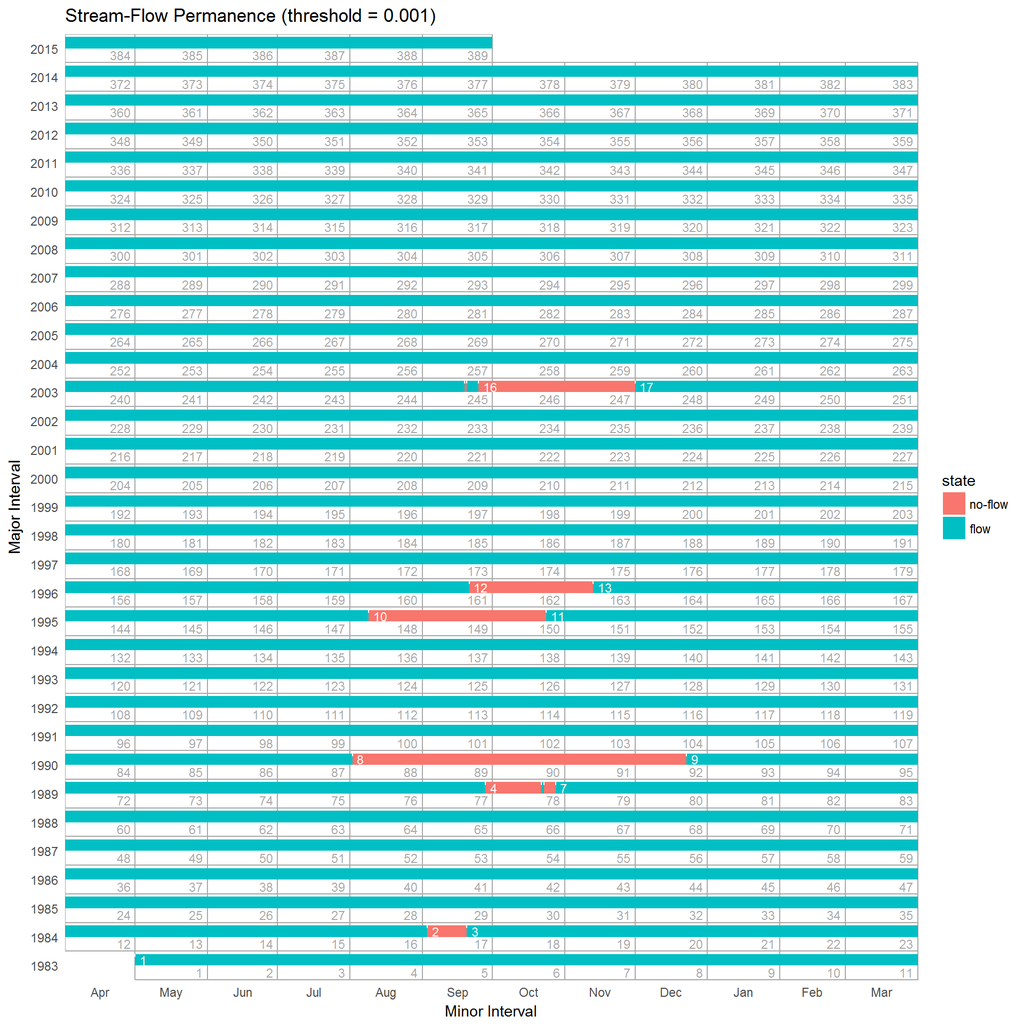

```r
ampney <- smires(ampneyBrook, major = 91, minor = intervals$month, rule = "onset", plot = TRUE)
```

The first record of the data set exists for the date 1983-05-01 which starts the second month of our hydrological year 1983. The data set covers in total 33 years, of which 6 show a `no-flow` event.

# 2 Flow/No-flow spell characteristics

A characteristic that can be calculated for **no-flow** spells can also be calculated for **flow** spells. The following sections demonstrate just the calculation of no-flow spell characteristics.

## 2.1 General characteristics

Each of the following sections start with a table, showing all metrics attributed to this certain section. This section ‘General characteristics’ comprises just one characteristic, the proportion of no-flow years $f_0$ .

| Name | Acronym | Function | Description |
| --- | --- | --- | --- |
| Proportion of no-flow years | $f_0$ | `no_flow_years(x)` | Number of years with no-flow occurrence (when flow is at least for one day below the no-flow threshold) divided by the study period in years |

Using the same example as before this metric is defined as

$$f_0 = \frac{\textrm{Number of no-flow years}}{\textrm{Number of years in study period}} = \frac{6}{33} = 0.1818182= 18.2 \%$$

and can be calculated using the function:

```r
no_flow_years(ampneyBrook)
```

```
##        f0
## 0.1818182
```

## 2.2 Number of no-flow days

| Name | Measure | Acronym | Function | Description |
| --- | --- | --- | --- | --- |
| Mean annual number of no-flow days | Location | $MAN$ | `MAN(x)` | Mean annual number of days with no-flow occurrence (when flow is below the no-flow threshold) |
| CV of the annual number of no-flow days | Variability | $CVAN$ | `CVAN(x)` | Coefficient of variation of the annual number of days with no-flow occurrence (when flow is below the no-flow threshold) |
| Distribution of the annual number of no-flow days | Distribution | $FAN$ | `FAN(x)` | Statistical distribution (cdf) of the annual number of days with no-flow occurrence (when flow is below the no-flow threshold) |

## 2.3 Duration

| Name | Measure | Acronym | Function | Description |
| --- | --- | --- | --- | --- |
| Mean annual maximum duration | Location | $MAMD$ | `MAMD(x)` | Mean duration of the longest annual no-flow event (during which flow remains below the no-flow threshold) |
| CV of annual maximum duration | Variability | $CVAMD$ | `CVAMD(x)` | Coefficient of variation of the duration of the longest annual no-flow event (during which flow remains below the no-flow threshold) |
| Distribution of annual maximum duration | Distribution | $FAMD$ | `FAMD(x)` | Statistical distribution (cdf) of the duration of the longest annual no-flow event (during which flow remains below the no-flow threshold) |

```r
MAMD(ampneyBrook)
```

```
##     MAMD
## 11.51515
```

## 2.4 Timing and seasonality

| Name | Measure | Acronym | Function | Description |
| --- | --- | --- | --- | --- |
| Mean onset | Location | $\tau_0$ | `tau0(x)` | Mean Julian date (day-of-year) of the first annual no-flow day (using circular statistics) |
| Variability of onset | Variability | $\tau_{0r}$ | `tau0r(x)` | Circular variability index r (between 0 and 1) of the onset |
| Mean termination | Location | $\tau_E$ | `tauE(x)` | Mean Julian date (day-of-year) of the first annual no-flow day (using circular statistics) |
| Variability of termination | Variability | $\tau_{Er}$ | `tauEr(x)` | Circular variability index r (between 0 and 1) of the termination |
| Mean seasonality | Location | $\tau$ | `tau(x)` | Mean Julian date of all no-flow days (using circular statistics) |
| Strength of seasonality | Variability | $\tau_r$ | `taur(x)` | Circular variability index r (between 0 and 1) of all no-flow days |

```r
tau0(ampneyBrook)
```

[output not shown]

# 3 Rate of change before/after no-flow event

| Name | Measure | Acronym | Function | Description |
| --- | --- | --- | --- | --- |
| Mean recession rate | Location | $k$ | `k(x)` | Mean rate of decay of the hydrograph during flow recession periods |
| Standard deviation of recession rate | Variability | $k_{sd}$ | `ksd(x)` | Standard deviation of rate of decay of the hydrograph during flow recession periods |
| Mean annual number of reversals in flow magnitude | Location | $n_{rv}$ | `nrv(x)` | Mean annual number of reversals in flow magnitude |

```r
k(ampneyBrook)
```

```
## [1] 0.9676343
```